# How Resilient Is Seattle’s Transit Network?

Chokepoints and fragmentation in the King County Metro GTFS network

Siri Suwannatee (Ty)

November 19, 2026

# 1 Summary

This project treats Seattle’s transit system as a network and asks what happens when stops fail. Each stop in the King County Metro schedule feed is a node, and two stops are tied when a vehicle serves them back to back on a trip. The network has 6,271 stops and 7,025 ties. I describe its structure, rank stops by betweenness centrality to find the bridges between neighborhoods, and then remove stops in three ways (at random, by highest degree, and by highest betweenness) while tracking the size of the largest connected piece.

Two results stand out.

1. **The biggest chokepoint is the SR 520 floating bridge corridor, not downtown Seattle.** The five highest-betweenness stops all sit on it, and each has only 4 to 7 direct connections.
2. **Fragmentation does not follow the usual textbook pattern.** Removing the highest-degree stops broke the network fastest. After 5% of stops were removed, the largest connected piece fell from 99.5% to about 42% of stops. Betweenness-targeted removal halved the network at about 14% removed, and random removal at about 17%.

The network is mostly long chains of stops joined by a thin layer of junctions, and that structure explains why it fails the way it does.

# 2 Data and Setup

## 2.1 Packages

```r
library(readr)     # reading the CSV files
library(dplyr)     # data wrangling
library(tidyr)     # reshaping data for plots
library(tibble)    # tidy tables
library(knitr)     # clean tables
library(igraph)    # network analysis
library(ggraph)    # network visualization
library(ggplot2)   # general plotting

theme_set(theme_minimal(base_size = 12))
```

## 2.2 About the data

The data come from the King County Metro General Transit Feed Specification (GTFS) schedule feed, published by King County Metro Transit and available at https://metro.kingcounty.gov/GTFS/google_transit.zip (mirror: https://www.soundtransit.org/GTFS-KCM/google_transit.zip). I downloaded it on November 18, 2026. It is version FAL26-161.5 and covers scheduled service from October 29, 2026 to March 26, 2027. GTFS is the standard open format transit agencies use to publish schedules. This feed includes Metro bus service, the Seattle Streetcar, the King County Water Taxi, Sound Transit Link light rail, and some Sound Transit Express service (142 routes and 31,484 trips). Because GTFS is schedule data, the network shows planned service, not ridership or real-time operations.

I converted the feed into two tables by sorting `stop_times.txt` by trip and stop sequence and linking each stop to the next one:

- `nodes.csv` has one row per stop: `id`, `name`, `x` and `y` (longitude and latitude), plus precomputed `degree` and `betweenness` used for checking.
- `edges.csv` has one row per tie: `from` and `to`, the stop ids served consecutively on at least one trip.

The network is one-mode, undirected, and unweighted. A tie means that a vehicle travels directly between two stops, in either direction.

> Data credit (required by King County): *Transit scheduling, geographic, and real-time data provided by permission of King County.*

## 2.3 Building the graph

```r
nodes <- read_csv("nodes.csv", show_col_types = FALSE)
edges <- read_csv("edges.csv", show_col_types = FALSE)

g <- graph_from_data_frame(d = edges, vertices = nodes, directed = FALSE)

g
```

```
## IGRAPH 6e48c5a UN-- 6271 7025 --
## + attr: name (v/c), x (v/n), y (v/n), degree (v/n), betweenness (v/n)
## + edges from 6e48c5a (vertex names):
##  [1] 9th Ave & Alder St   --Boren Ave & Seneca St
##  [2] 9th Ave & Alder St   --Yesler Way & 3rd Ave
##  [3] 9th Ave & Alder St   --9th Ave & Jefferson St
##  [4] 9th Ave & Alder St   --Yesler & Broadway
##  [5] Yesler Way & 3rd Ave --3rd Ave & James St
##  [6] Yesler Way & 3rd Ave --Yesler Way & 5th Ave
##  [7] Yesler Way & 3rd Ave --1st Ave & Marion St
##  [8] 1st Ave & Marion St  --1st Ave & Pine St
## + ... omitted several edges
```

The graph has 6,271 nodes and 7,025 ties. These counts use raw stop IDs. The same physical stop is often split into several IDs by direction or bay, so I test a merged version in the sensitivity check near the end.

# 3 Exploring the Network

## 3.1 Map of the network

The plot uses each stop’s real longitude and latitude, so the network keeps the shape of the region. Node size shows betweenness centrality (how often a stop lies on shortest routes between other stops). Node color shows degree (the number of direct connections). The five highest-betweenness stops are ringed in red.

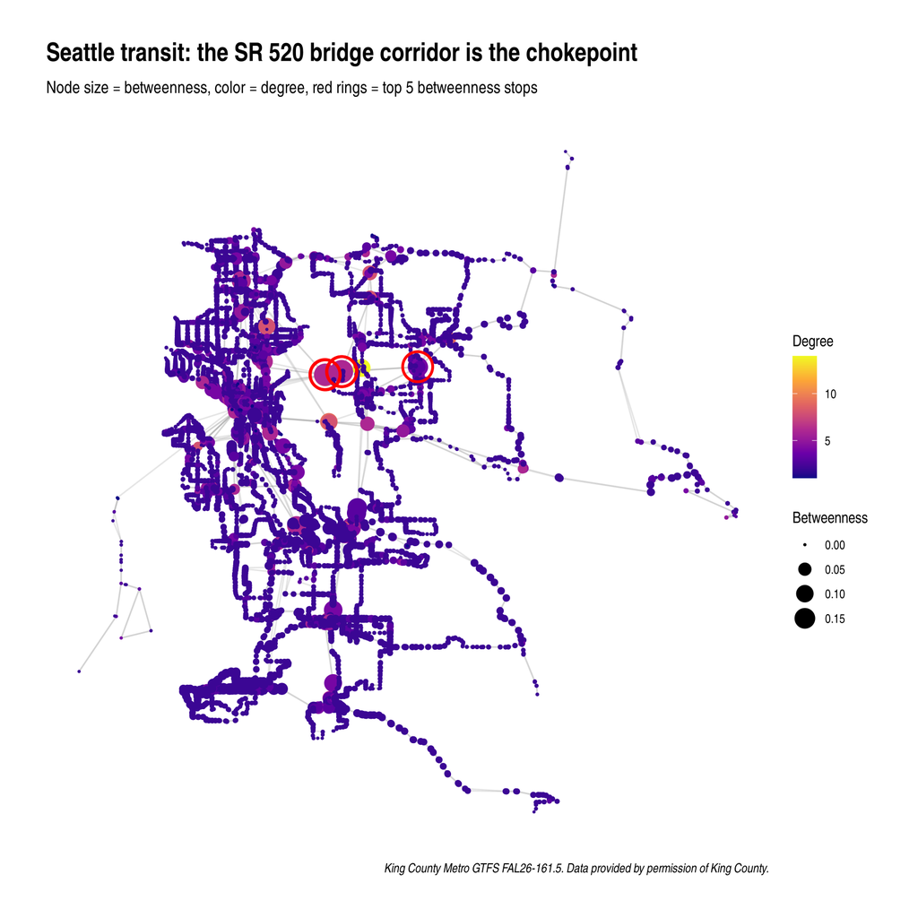

```r
V(g)$betweenness_r <- betweenness(g, directed = FALSE, normalized = TRUE)
top5 <- V(g)$name[order(-V(g)$betweenness_r, V(g)$name)][1:5]
V(g)$is_top5 <- V(g)$name %in% top5

ggraph(g, layout = "manual", x = V(g)$x, y = V(g)$y) +
  geom_edge_link(alpha = 0.25, colour = "grey60") +
  geom_node_point(aes(size = betweenness_r, colour = degree)) +
  geom_node_point(aes(filter = is_top5), shape = 21, size = 9,
                  stroke = 1.4, colour = "red", fill = NA) +
  scale_colour_viridis_c(option = "plasma", name = "Degree") +
  scale_size_continuous(name = "Betweenness", range = c(0.4, 7)) +
  labs(title = "Seattle transit: the SR 520 bridge corridor is the chokepoint",
       subtitle = "Node size = betweenness, color = degree, red rings = top 5 betweenness stops",
       caption = "King County Metro GTFS FAL26-161.5. Data provided by permission of King County.") +
  theme_graph()
```

The network is dense on the west side (Seattle itself) and thins into long suburban chains to the east and south. The red-ringed stops all sit on the SR 520 corridor at the east end of the floating bridge, the main crossing of Lake Washington. The largest dots are not the yellowest ones: the bridge stops have modest degree (4 to 7) but very high betweenness. They act as brokers, not hubs.

## 3.2 Degree distribution

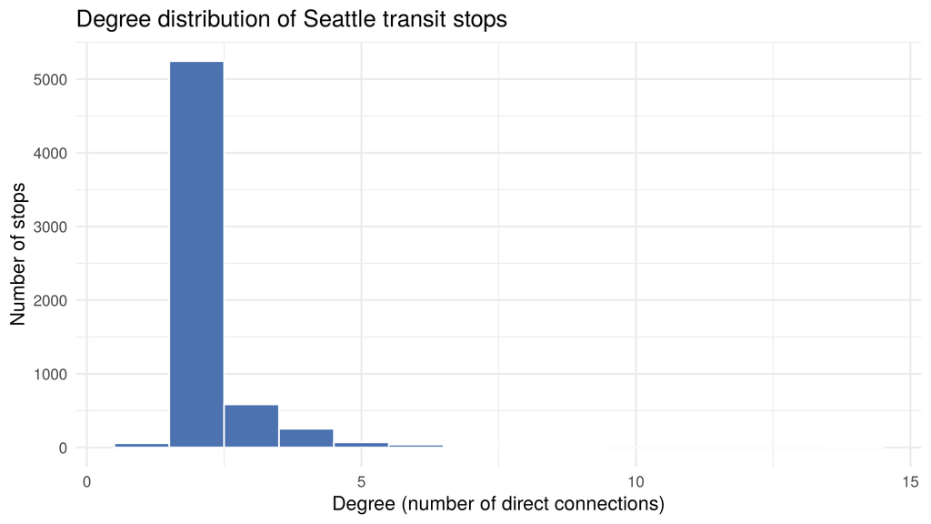

```r
tibble(degree = degree(g)) %>%
  ggplot(aes(x = degree)) +
  geom_histogram(binwidth = 1, fill = "#4C72B0", colour = "white") +
  labs(title = "Degree distribution of Seattle transit stops",
       x = "Degree (number of direct connections)", y = "Number of stops")
```

This is not a hub-dominated, scale-free distribution. About 84% of stops have degree exactly 2: the stop before and the stop after on a route. The average degree is 2.24 and the maximum is 14 (South Kirkland Park & Ride). Only 382 stops have degree 4 or more. Most of the analysis below follows from this chain-like structure.

# 4 Analysis

## 4.1 Basic structure

```r
n_components   <- components(g)$no
largest_share  <- max(components(g)$csize) / vcount(g)
clustering_avg <- transitivity(g, type = "average")
diam_lcc       <- diameter(g, directed = FALSE)
avg_path       <- mean_distance(g, directed = FALSE)

tibble(
  Measure = c("Nodes", "Ties", "Components", "Largest component share",
              "Average clustering", "Diameter (stops)", "Average shortest path (stops)"),
  Value   = c(vcount(g), ecount(g), n_components,
              round(largest_share, 4), round(clustering_avg, 4),
              diam_lcc, round(avg_path, 2))
) %>%
  kable()
```

| Measure | Value |
| --- | --- |
| Nodes | 6271.0000 |
| Ties | 7025.0000 |
| Components | 4.0000 |
| Largest component share | 0.9947 |
| Average clustering | 0.0143 |
| Diameter (stops) | 93.0000 |
| Average shortest path (stops) | 28.6700 |

The network is nearly one connected system: the largest component holds 99.47% of stops. Clustering is very low (0.014) because routes are chains and rarely close into triangles. Trips are long when counted in stops, with an average shortest path of about 29 stops and a diameter of 93.

The four components are:

- the mainland network (6,238 stops),
- a 29-stop component of Vashon Island bus stops, reachable from the mainland only by ferry in real life, and
- two 2-stop Water Taxi components.

The Water Taxi split is a data artifact. The two routes share Colman Dock in reality, but the feed gives the dock a different stop ID for each route, so the graph cannot see the transfer. I left it in because it shows how data conventions shape network structure.

## 4.2 Betweenness: finding the bridges

```r
tibble(Stop = V(g)$name,
       Betweenness = round(V(g)$betweenness_r, 3),
       Degree = degree(g)) %>%
  arrange(desc(Betweenness)) %>%
  slice_head(n = 10) %>%
  kable()
```

| Stop | Betweenness | Degree |
| --- | --- | --- |
| Sr 520 & 92nd Avenue Northeast | 0.195 | 6 |
| Sr 520 & Evergreen Point Rd | 0.186 | 7 |
| Sr 520 & Evergreen Point Rd | 0.163 | 6 |
| Sr 520 & 92nd Ave NE | 0.141 | 4 |
| Sr 520 & NE 40th St | 0.137 | 4 |
| Rainier Ave S & S 7th St | 0.136 | 5 |
| Renton Transit Center - Bay 4 | 0.135 | 5 |
| Southport Dr N & Lake Washington Blvd N | 0.130 | 3 |
| Bellevue Transit Center - Bay 6 | 0.128 | 2 |
| Park Ave N & N 8th St | 0.127 | 3 |

One corridor dominates the top of the ranking. SR 520 & 92nd Ave NE has betweenness of about 0.195 and degree 6, and the Evergreen Point stops sit at the east end of the bridge. Six of the top 20 stops are on SR 520. A smaller group sits around Renton Transit Center. No Link light rail station and no stop in the downtown core appears in the top 20. Downtown has many parallel routes, which probably spreads shortest paths across dozens of stops so that no single one is critical. The fragile points are in the suburbs, where one bridge or one arterial carries most of the traffic between areas.

The ranking also shows the broker pattern. Bellevue Transit Center - Bay 6 has degree 2 but ranks 9th by betweenness. A degree-only analysis would call it unimportant, while betweenness shows it is a key link between two chains.

## 4.3 Resilience test: three ways to break the network

The main experiment removes stops in 1% steps up to 50% removed, using three strategies:

- **Random** failure (mean of 10 trials), as a model of everyday disruption.
- **Degree-targeted** removal, best-connected stops first.
- **Betweenness-targeted** removal, biggest bridges first.

After each step I record the size of the largest remaining component as a fraction of the original 6,271 stops.

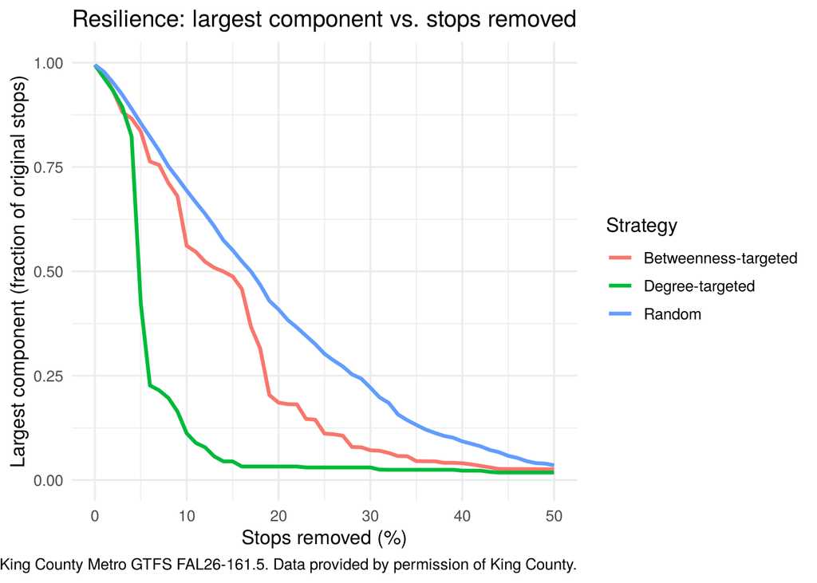

```r
set.seed(20261118)

largest_fraction <- function(graph) {
  if (vcount(graph) == 0) return(0)
  max(components(graph)$csize) / vcount(g)
}

attack_curve <- function(order_names, steps = 0:50) {
  sapply(steps, function(p) {
    k <- floor(p / 100 * vcount(g))
    if (k == 0) return(largest_fraction(g))
    largest_fraction(delete_vertices(g, order_names[seq_len(k)]))
  })
}

steps <- 0:50
deg_order <- V(g)$name[order(-degree(g), V(g)$name)]
bet_order <- V(g)$name[order(-V(g)$betweenness_r, V(g)$name)]

resilience <- tibble(
  pct_removed = steps,
  `Degree-targeted`      = attack_curve(deg_order, steps),
  `Betweenness-targeted` = attack_curve(bet_order, steps),
  Random = rowMeans(replicate(10, attack_curve(sample(V(g)$name), steps)))
)

resilience %>%
  tidyr::pivot_longer(-pct_removed, names_to = "Strategy", values_to = "Largest component") %>%
  ggplot(aes(x = pct_removed, y = `Largest component`, colour = Strategy)) +
  geom_line(linewidth = 1.1) +
  scale_y_continuous(limits = c(0, 1)) +
  labs(title = "Resilience: largest component vs. stops removed",
       x = "Stops removed (%)", y = "Largest component (fraction of original stops)",
       caption = "King County Metro GTFS FAL26-161.5. Data provided by permission of King County.")
```

This differs from the standard textbook result. In hub-dominated networks, degree-targeted attacks are devastating, betweenness attacks are usually comparable, and random failure does little harm. Here:

- Degree-targeted removal fragments the network fastest. The largest component drops below 50% at 5% removed, with about 42% of stops still in it at that point.
- Betweenness-targeted removal halves the network at about 14% removed.
- Random removal halves it at about 17%. Even random failure does real damage, because with an average degree of 2.24 there is little redundancy anywhere.

A note on reproducibility: many stops share the same degree, so the exact degree-attack curve depends on how ties are broken. The orders above break ties by stop name, which makes this page reproducible. The ranking of the three strategies (degree fastest, then betweenness, then random) should hold under other tie-breaking choices, but the exact percentages can shift by a few points.

Why does the degree attack win? In a chain-like network the high-degree stops are not a few superstar hubs. They are the whole junction layer (all 382 stops with degree 4 or more) that ties the routes together, and removing them cuts the chains apart everywhere at once. The top-betweenness stops, by contrast, sit in series along a few corridors like SR 520. Once the first bridge stop is gone, its neighbors lose most of their betweenness too, so a static betweenness attack spends many removals on corridors that are already cut.

## 4.4 A second measure: do trips survive, and at what cost?

Largest-component size shows when the network splits, but not when it stops being usable. As a second measure I sampled 300 pairs of stops and, at each removal step, recorded the share of pairs still connected and the average shortest path among the pairs that remain connected.

```r
set.seed(20261118)
lcc <- induced_subgraph(g, names(which(components(g)$membership ==
                                       which.max(components(g)$csize))))
pair_sample <- replicate(300, sample(V(lcc)$name, 2), simplify = FALSE)

pair_stats <- function(order_names, steps = 0:50) {
  t(sapply(steps, function(p) {
    k <- floor(p / 100 * vcount(g))
    h <- if (k == 0) g else delete_vertices(g, order_names[seq_len(k)])
    d <- sapply(pair_sample, function(pr) {
      if (!all(pr %in% V(h)$name)) return(NA_real_)
      dd <- distances(h, v = pr[1], to = pr[2])[1, 1]
      ifelse(is.infinite(dd), NA_real_, dd)
    })
    c(share_connected = mean(!is.na(d)), avg_path = mean(d, na.rm = TRUE))
  }))
}

path_deg <- pair_stats(deg_order)
path_bet <- pair_stats(bet_order)

# Selected rows, printed so the numbers quoted below can be checked.
tibble(`Removed (%)` = steps,
       `Degree: pairs connected` = round(path_deg[, "share_connected"], 3),
       `Degree: avg path` = round(path_deg[, "avg_path"], 1),
       `Betweenness: pairs connected` = round(path_bet[, "share_connected"], 3),
       `Betweenness: avg path` = round(path_bet[, "avg_path"], 1)) %>%
  filter(`Removed (%)` %in% c(0, 2, 4, 6, 8, 10, 15, 20)) %>%
  kable()
```

| Removed (%) | Degree: pairs connected | Degree: avg path | Betweenness: pairs connected | Betweenness: avg path |
| --- | --- | --- | --- | --- |
| 0 | 1.000 | 29.0 | 1.000 | 29.0 |
| 2 | 0.870 | 69.2 | 0.903 | 56.8 |
| 4 | 0.720 | 97.8 | 0.773 | 69.4 |
| 6 | 0.110 | 50.4 | 0.603 | 72.2 |
| 8 | 0.073 | 47.7 | 0.537 | 101.1 |
| 10 | 0.030 | 39.9 | 0.330 | 88.6 |
| 15 | 0.007 | 5.0 | 0.257 | 95.8 |
| 20 | 0.007 | 5.0 | 0.073 | 52.9 |

I did not run this measure for random removal. Two points come out of the table.

First, pair connectivity falls at least as fast as the largest component. Under the degree attack the share of connected pairs drops from 72% at 4% removed to 26% at 5%, so it falls below half at 5%. Under the betweenness attack it falls below half at about 10% removed, compared with 14% for the largest component. A trip fails if either endpoint is removed or if the path between them is cut.

Second, trips get much longer before they become impossible. Under the betweenness attack the average path among surviving pairs grows from 29 stops to about 100 stops by 7 to 9% removed (a peak of about 107 at 9%). Under the degree attack it reaches about 98 stops at 4% removed. Removing junctions and bridges forces long detours along the chains.

After the peak, average path length falls again. That is not a recovery. It happens because only short local trips are still possible, so the average is taken over a shrinking and increasingly local set of pairs. The two measures should be read together: the largest component shows when the network splits, and path length shows when it stops being usable.

## 4.5 Sensitivity check: does merging duplicate stops change the answer?

The counts above use raw stop IDs, but agencies often split one physical stop into several IDs by direction or bay. For example, Sr 520 & Evergreen Point Rd holds both the #2 and #3 betweenness ranks. The usual merging key, `parent_station`, is blank for all 6,271 stops in this feed, so I merged stops with the same name and the same coordinates rounded to 3 decimal places.

```r
nodes_merged <- nodes %>%
  mutate(key = paste(name, round(x, 3), round(y, 3))) %>%
  group_by(key) %>%
  summarise(id_new = first(id), x = mean(x), y = mean(y), .groups = "drop")

id_map <- nodes %>%
  mutate(key = paste(name, round(x, 3), round(y, 3))) %>%
  left_join(nodes_merged %>% select(key, id_new), by = "key") %>%
  select(id, id_new)

edges_merged <- edges %>%
  left_join(id_map, by = c("from" = "id")) %>% rename(from_new = id_new) %>%
  left_join(id_map, by = c("to" = "id"))   %>% rename(to_new = id_new) %>%
  filter(from_new != to_new) %>%
  distinct(from = from_new, to = to_new)

g_merged <- graph_from_data_frame(edges_merged,
                                  vertices = nodes_merged %>% rename(id = id_new) %>%
                                    select(id, x, y),
                                  directed = FALSE)
c(nodes_merged = vcount(g_merged), ties_merged = ecount(g_merged),
  largest_share_merged = round(max(components(g_merged)$csize) / vcount(g_merged), 4))
```

```
##         nodes_merged          ties_merged largest_share_merged
##            5390.0000            6976.0000               0.9946
```

Merging removes 881 duplicate stop IDs and gives 5,390 nodes and 6,976 ties. The largest component still holds 99.46% of stops, and the corridor chokepoints stay the same. The main results do not depend on the stop-ID convention. I keep the raw-ID network as the primary analysis because it is the feed’s own unit, and I treat the merged network as a robustness check.

# 5 Takeaways

Seattle’s transit network is held together by a thin layer of modest junctions and a few bridges, strung between long chains of ordinary stops. That structure makes it fragile in a specific way. Random failures are survivable but not cheap, because a chain network has little redundancy. The worst failures are concentrated and predictable. Removing 5% of stops by degree cuts the largest connected piece from 99.5% to about 42% of the network, and removing high-betweenness stops makes the trips that still work far longer (about 29 stops growing to about 107 at 9% removed).

For a transit agency, the practical lesson is that resilience planning should protect brokers and junctions, not only the busiest stations. The stop that matters most may have only two connections and a name nobody recognizes.

This project is also a reminder not to import textbook expectations into real networks. The usual finding that networks are robust to random failure but fragile to targeted attack assumes a hub-dominated degree distribution, which this network does not have. Measuring the network’s structure first is what showed that degree removal, not betweenness removal, is the most damaging attack here.

# 6 Sources and Credits

Data: King County Metro GTFS feed, version FAL26-161.5, downloaded November 18, 2026, from https://metro.kingcounty.gov/GTFS/google_transit.zip. Transit scheduling, geographic, and real-time data provided by permission of King County. Analysis and visualization in R with igraph and ggraph.